# Introducción a la Econometria

## El modelo de regresión lineal simple

### El modelo general

Un modelo de regresión lineal simple supone que existe una relación lineal entre la expectativa condicional de una **variable dependiente**, $y$, y una **variable independiente**, $X$.

[output not shown]

La relación supuesta en un modelo de regresión lineal tiene la forma

$$y_i=β_1+β_2*x_i+e_i \hspace{40pt}................................(1)$$
donde:

- $y$ : es la variable dependiente
- $x$ : es la variable independiente
- $e$ : es un termino de error
- $\sigma^2$ : es la varianza del término de error
- $β_1$ : es el parametro de intercepción o coeficiente
- $β_2$ : es el parametro de pendiente o coeficiente
- $i$ : representa la i -ésima observación en el conjunto de datos, i = 1 , 2 , . . . , N
- $N$ : es el número de observaciones en el conjunto de datos.

El valor predicho o estimado de y dado X está dada por la ecuación 2; en general, el símbolo del sombrero indica un valor estimado o predicho.

$$\hat{y} = b_1 + b_2
*x \hspace{40pt}................................(2)$$

El modelo de regresión lineal simple supone que los valores de X son elegidos previamente (por lo tanto, no son aleatorios), que la varianza del término de error, $\sigma^2$, es el mismo para todos los valores de X, y que no hay conexión entre una observación y otra (no hay correlación entre los términos de error de dos observaciones). Además, se supone que el valor esperado del término de error para cualquier valor de $X$ es cero

El subíndice i en la ecuación 1 indica que la relación se aplica a cada uno de los N observaciones. Por lo tanto, debe haber valores específicos de y, X, e para cada observación. Sin embargo, dado que x no es aleatorio, normalmente hay varias observaciones que comparten la misma x , como muestra el diagrama de dispersión de la Figura 2.1.

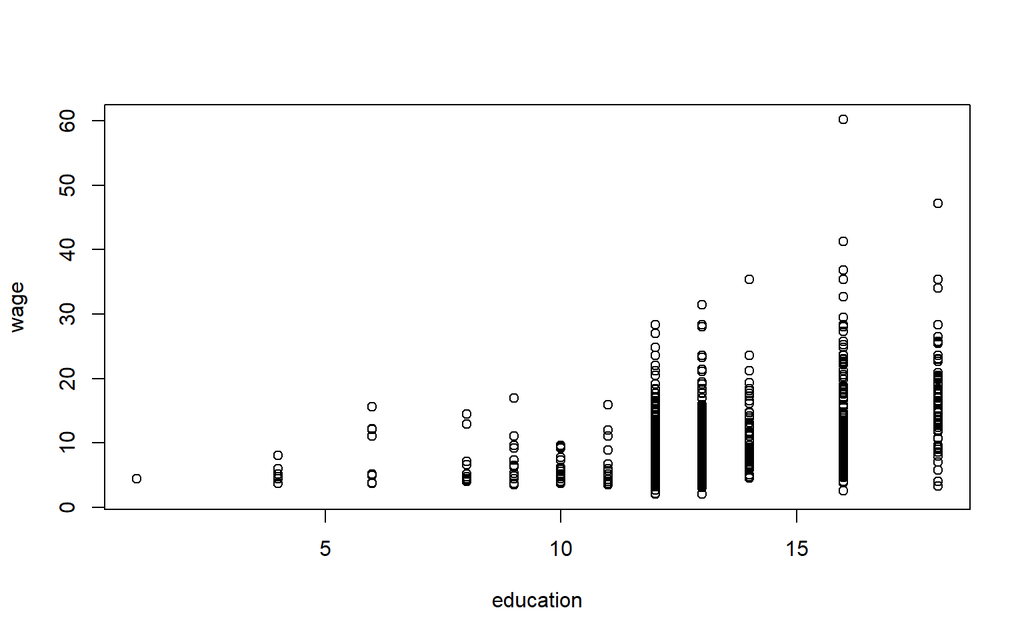

```r
library(PoEdata)
data("cps_small")
plot(cps_small$educ, cps_small$wage,
     xlab="education", ylab="wage")
```

### Ejemplo: gasto en alimentos versus ingresos

Los datos de este ejemplo se almacenan en el paquete PoEdata de R.

```r
library(PoEdata)
data(food)
head(food)
```

| food_exp | income |
| --- | --- |
| 115.2 | 3.69 |
| 136 | 4.39 |
| 119.3 | 4.75 |
| 115 | 6.03 |
| 187.1 | 12.47 |
| 243.9 | 12.98 |

Siempre es una buena idea inspeccionar visualmente los datos en un diagrama de dispersión, que se puede crear utilizando la plot(). La figura 2.2 es un diagrama disperso del gasto en alimentos sobre los ingresos, lo que sugiere que existe una relación positiva entre los ingresos y el gasto en alimentos.

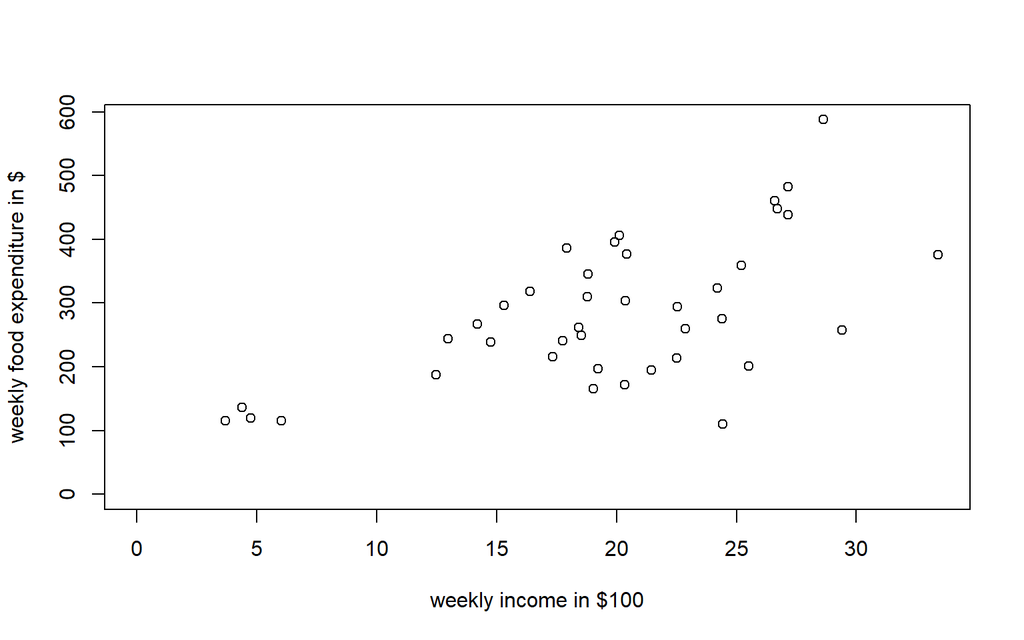

```r
data("food", package="PoEdata")
plot(food$income, food$food_exp,
     ylim=c(0, max(food$food_exp)),
     xlim=c(0, max(food$income)),
     xlab="weekly income in $100",
     ylab="weekly food expenditure in $",
     type = "p")
```

### Estimación de una regresión lineal

La función R para estimar un modelo de regresión lineal es `lm(y~x, data)`.

Es útil dar un nombre al modelo, como mod1, y luego mostrar los resultados usando `summary(mod1)`. Si está interesado solo en algunos de los resultados de la regresión, como los coeficientes estimados, puede recuperarlos utilizando funciones específicas, como la función `coef()`. Para los datos de gasto alimentario, el modelo de regresión será:

$$foodexp = β_1+β_2*income+e
\hspace{40pt}................................(3)$$

donde el subíndice i se ha omitido por simplicidad

```r
library(PoEdata)
mod1 <- lm(food_exp ~ income, data = food)
b1 <- coef(mod1)[[1]]
b2 <- coef(mod1)[[2]]
smod1 <- summary(mod1)
smod1
```

|  | Estimate | Std. Error | t value | Pr(>\|t\|) |
| --- | --- | --- | --- | --- |
| **(Intercept)** | 83.42 | 43.41 | 1.922 | 0.06218 |
| **income** | 10.21 | 2.093 | 4.877 | 1.946e-05 |

Fitting linear model: food_exp ~ income

| Observations | Residual Std. Error | $R^2$ | Adjusted $R^2$ |
| --- | --- | --- | --- |
| 40 | 89.52 | 0.385 | 0.3688 |

La función coef() devuelve una lista que contiene los coeficientes estimados, donde se puede acceder a un coeficiente específico mediante su posición en la lista.Por ejemplo, el valor estimado de β1 es b1 <- coef(mod1)[[1]], que es igual a 83.416002, y el valor estimado de β2 es bb2 <- coef(mod1)[[2]], que es igual a 10.209643.

El parámetro de intercepción, β1, suele tener poca importancia en los modelos econométricos; Estamos interesados principalmente en el parámetro de pendiente, β2. El valor estimado de β2 sugiere que el gasto en alimentos para una familia promedio aumenta en 10.209643 cuando el ingreso familiar aumenta en 1 unidad, que en este caso es de $ 100. El function abline() agrega la línea de regresion al diagrama de dispersión previamente trazado, como muestra la Figura 2.3.

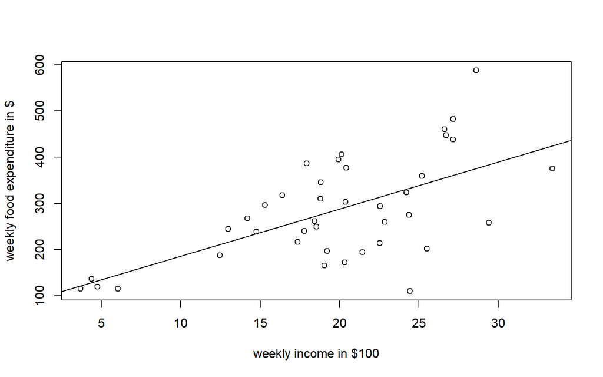

```r
plot(food$income, food$food_exp,
     xlab="weekly income in $100",
     ylab="weekly food expenditure in $",
     type = "p")
abline(b1,b2)
```

¿Cómo se pueden recuperar varios resultados de regresión? Estos resultados existen en dos objetos R producidos por la función lm() el objeto de regresión, como mod1 en la secuencia de código anterior, y el resumen de regresión, que denoté por smod1. El código siguiente muestra cómo enumerar los nombres de todos los resultados de cada objeto.

```r
names(mod1)
```

```
##  [1] "coefficients"  "residuals"     "effects"       "rank"
##  [5] "fitted.values" "assign"        "qr"            "df.residual"
##  [9] "xlevels"       "call"          "terms"         "model"
```

```r
names(smod1)
```

```
##  [1] "call"          "terms"         "residuals"     "coefficients"
##  [5] "aliased"       "sigma"         "df"            "r.squared"
##  [9] "adj.r.squared" "fstatistic"    "cov.unscaled"
```

Para recuperar un resultado en particular, simplemente refiérase a él con el nombre del objeto, seguido del signo $\$$ y el nombre del resultado que desea recuperar. Por ejemplo, si queremos el vector de coeficientes de mod1, nos referimos a él como `mod1$coefficients` y `smod1$coefficients` `mod1$coefficients`:

```r
mod1$coefficients
```

| (Intercept) | income |
| --- | --- |
| 83.42 | 10.21 |

```r
smod1$coefficients
```

|  | Estimate | Std. Error | t value | Pr(>\|t\|) |
| --- | --- | --- | --- | --- |
| **(Intercept)** | 83.42 | 43.41 | 1.922 | 0.06218 |
| **income** | 10.21 | 2.093 | 4.877 | 1.946e-05 |

Sin embargo, como hemos visto antes, algunos de estos resultados se pueden recuperar utilizando funciones específicas, como coef (mod1), resid(mod1) (mod1), fitted(mod1), vcov(mod1), coef(mod1), fitted(mod1).

### Predicción con el Modelo de Regresión Lineal

Los parámetros de regresión estimados, $b_1$ y $b_2$ nos permiten predecir el gasto alimentario esperado para cualquier ingreso dado. Todo lo que necesitamos hacer es conectar los valores de los parámetros estimados y el ingreso dado en una ecuación como Ecuación 2. Por ejemplo, el valor esperado de food_exp para un ingreso de $2000 se calcula en la Ecuación 4. (Recuerde dividir el ingreso por 100, ya que los datos para la variable income está en cientos de dólares)

$$\hat{foodexp} = 83.416002 + 10.209643∗20
= 287.608861
\hspace{35pt}................................(4)$$

R, sin embargo, hace estos cálculos por nosotros con su función llamada predict(). Extendamos ligeramente el ejemplo a más de un ingreso para el cual predecimos el gasto en alimentos, digamos ingresos = $\$$ 2000, $\$$ 2500 y $\$$ 2700. La función predict() en R requiere que los nuevos valores de las variables independientes se organicen bajo una forma particular, llamada marco de datos. Incluso cuando solo queremos predecir un ingreso, necesitamos la misma estructura de marco de datos. En R, un conjunto de números se mantiene unido usando la estructura c(). La siguiente secuencia muestra este ejemplo.

```r
# library(PoEdata) (load the data package if you have not done so yet)
mod1 <- lm(food_exp~income, data=food)
newx <- data.frame(income = c(20, 25, 27))
yhat <- predict(mod1, newx)
names(yhat) <- c("income=$2000", "$2500", "$2700")
yhat  # prints the result
```

| income=$2000 | $2500 | $2700 |
| --- | --- | --- |
| 287.6 | 338.7 | 359.1 |

### Muestras repetidas para evaluar los coeficientes de regresión

Los coeficientes de regresión $b_1$ y $b_2$ son variables aleatorias, porque dependen de la muestra. Construyamos una serie de submuestras aleatorias a partir de los datos de alimentos y volvamos a calcular $b_1$ y $b_2$. Se puede construir una submuestra aleatoria usando la función sample(), como ilustra el siguiente ejemplo solo para $b_2$

```r
N <- nrow(food) # returns the number of observations in the dataset
C <- 50         # desired number of subsamples
S <- 38         # desired sample size

sumb2 <- 0
for (i in 1:C){   # a loop over the number of subsamples
  set.seed(3*i)   # a different seed for each subsample
  subsample <- food[sample(1:N, size=S, replace=TRUE), ]
  mod2 <- lm(food_exp~income, data=subsample)
  #sum b2 for all subsamples:
  sumb2 <- sumb2 + coef(mod2)[[2]]
}
print(sumb2/C, digits = 3)
```

```
## [1] 9.89
```

### Varianzas estimadas y covarianza de los coeficientes de regresión

Muchas aplicaciones requieren estimaciones de las varianzas y covarianzas de los coeficientes de regresión. R los almacena en la matriz `vcov()`:

```r
(varb1 <- vcov(mod1)[1, 1])
```

```
## [1] 1884.442
```

```r
(varb2 <- vcov(mod1)[2, 2])
```

```
## [1] 4.381752
```

```r
(covb1b2 <- vcov(mod1)[1,2])
```

```
## [1] -85.90316
```

### Relaciones no lineales

A veces, el diagrama de diagrama de dispersión o algunas consideraciones teóricas sugieren una relación no lineal. Las relaciones no lineales más populares implican logaritmos de las variables dependientes o independientes y funciones polinómicas.

El modelo cuadrático requiere el cuadrado de la variable independiente.

$$y_i = \beta_1+\beta_{2} x_{i}^{2} + e_i
\hspace{35pt}................................(5)$$

En R, las variables independientes que involucran operadores matemáticos pueden incluirse en una ecuación de regresión con la función `I()`. En el ejemplo siguiente se utiliza el dataset `br` del paquete *PoEdata*, que incluye los precios de venta y los atributos de 1080 casas en Baton Rouge, LA. `price` precio es el precio de venta en dólares, y `sqft` es el área de superficie en pies cuadrados.

```r
library(PoEdata)
data(br)
mod3 <- lm(price~I(sqft^2), data=br)
b1 <- coef(mod3)[[1]]
b2 <- coef(mod3)[[2]]
sqftx=c(2000, 4000, 6000) #given values for sqft
pricex=b1+b2*sqftx^2 #prices corresponding to given sqft
DpriceDsqft <- 2*b2*sqftx # marginal effect of sqft on price
elasticity=DpriceDsqft*sqftx/pricex
b1; b2; DpriceDsqft; elasticity #prints results
```

```
## [1] 55776.57
```

```
## [1] 0.0154213
```

```
## [1]  61.68521 123.37041 185.05562
```

```
## [1] 1.050303 1.631251 1.817408
```

Nos gustaría ahora dibujar un diagrama de dispersión y ver cómo la función cuadrática se ajusta a los datos. El siguiente fragmento de código proporciona dos alternativas para construir dicho gráfico. El primero simplemente dibuja la función cuadrática en el diagrama de dispersión, usando la función R curve(); El segundo utiliza las lines de función, lo que requiere ordenar el conjunto de datos en valores crecientes de `sqft` antes de que se evalúe el modelo de regresión, de modo que los valores ajustados resultantes también salgan en el mismo orden.

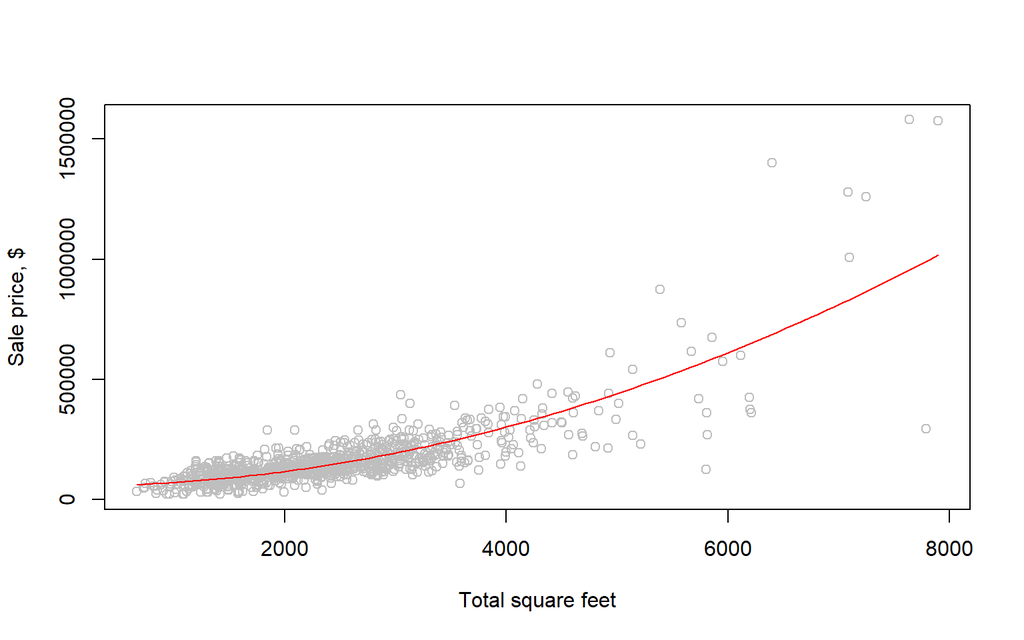

```r
mod31 <- lm(price~I(sqft^2), data=br)
plot(br$sqft, br$price, xlab="Total square feet",
     ylab="Sale price, $", col="grey")
#add the quadratic curve to the scatter plot:
curve(b1+b2*x^2, col="red", add=TRUE)
```

Una forma alternativa de dibujar la curva ajustada:

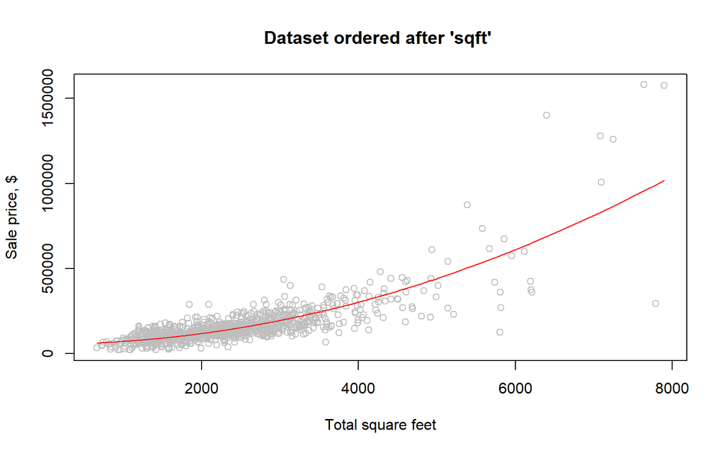

```r
ordat <- br[order(br$sqft), ] #sorts the dataset after `sqft`
mod31 <- lm(price~I(sqft^2), data=ordat)
plot(br$sqft, br$price,
     main="Dataset ordered after 'sqft' ",
     xlab="Total square feet",
     ylab="Sale price, $", col="grey")
lines(fitted(mod31)~ordat$sqft, col="red")
```

El modelo log-lineal hace una regresión logarítmica de la variable dependiente en una expresión lineal de la variable independiente (a menos que se especifique lo contrario, la notación log natural, siguiendo una convención habitual en economía):

$$log(y_i) = β_1+β_2 x_i + e_i
\hspace{35pt}................................(6)$$

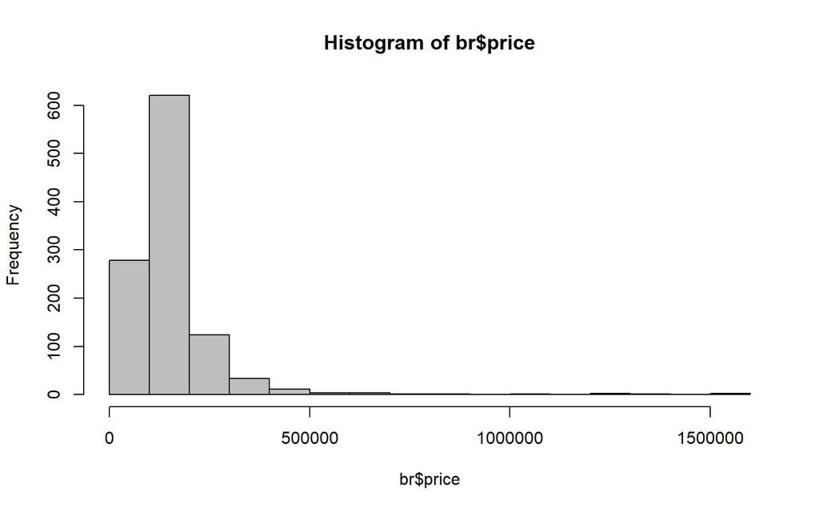

```r
hist(br$price, col='grey')
```

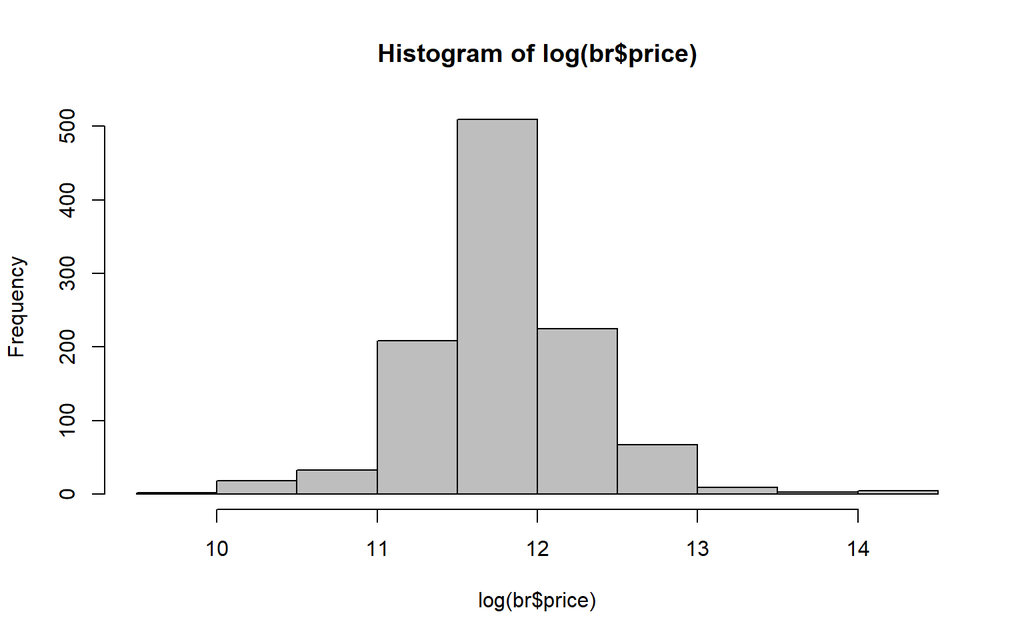

```r
hist(log(br$price), col='grey')
```

## Estimación de intervalos y pruebas de hipótesis

```r
library(xtable)
library(PoEdata)
library(knitr)
```

Hasta ahora, solo estimamos un número para un parámetro de regresión como β2. Esta estimación, sin embargo, no da ninguna indicación de su fiabilidad, ya que es sólo una realización de la variable aleatoria. b2. Una estimación de intervalo, que también se conoce como intervalo de confianza, es un intervalo centrado en un valor estimado, que incluye el parámetro verdadero con una probabilidad dada, digamos 95%. Un coeficiente del modelo de regresión lineal como b2 se distribuye normalmente con su media igual al parámetro de población β2 y una varianza que depende de la varianza de la población σ2 y el tamaño de la muestra: